# Exercice 3

# Tâche 1 : Réflexion

# Tâche 2 : Le Seigneur des Anneaux

## Charger et nettoyer les données

Nous chargeons, restructurons et nettoyons d’abord les données.

```r
# Vous n'aurez besoin que de la bibliothèque tidyverse pour cet exercice
library(tidyverse)

# Charger les jeux de données séparés
communauté <- read_csv("data/The_Fellowship_Of_The_Ring.csv")
tt <- read_csv("data/The_Two_Towers.csv")
rotk <- read_csv("data/The_Return_Of_The_King.csv")

# bind_rows() empile les blocs de données les uns sur les autres
lotr_wide <- bind_rows(communauté, tt, rotk) %>%
  # Faites de la colonne Film une variable catégorielle (facteur) et placez-la dans
  # ordonner l'apparition des catégories (pour que les films soient dans le bon ordre)
  mutate(Film = fct_inorder(Film))

# Rendez ces données larges bien rangées
lotr <- lotr_wide %>%
  # C'est la nouvelle façon de rendre les données longues
  pivot_longer(cols = c(Female, Male),
               names_to = "Sexe", values_to = "Mots")
```

## Course

Une certaine race domine-t-elle toute la trilogie ? (indice : regrouper par `Race`)

```r
# Faites des trucs ici
dominant_race <- lotr %>%
  group_by(Race) %>%
  summarise(Mots = sum(Mots, na.rm = TRUE))  %>%
  arrange(desc(Mots))
dominant_race
```

```
## # A tibble: 3 × 2
##   Race    Mots
##   <chr>  <dbl>
## 1 Hobbit  8796
## 2 Man     8712
## 3 Elf     3737
```

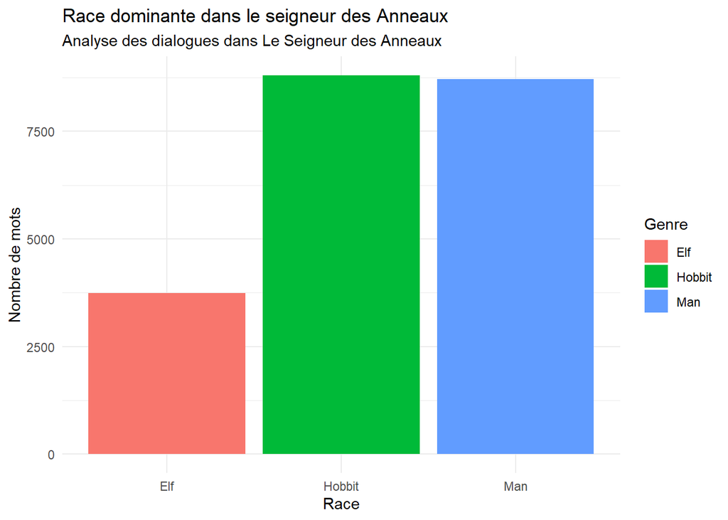

```r
ggplot(data=lotr,aes(x=Race,y=Mots,fill=Race))+
  geom_bar(stat="identity")+
  labs(
    title = "Race dominante dans le seigneur des Anneaux",
    subtitle = "Analyse des dialogues dans Le Seigneur des Anneaux",
    x = "Race",
    y = "Nombre de mots",
    fill = "Genre"
  )+
  theme_minimal()
```

## Genre et cinéma

Est-ce qu’un certain genre domine un film ? (lol bien sûr que c’est le cas, mais quand même, représentez-le graphiquement) (Astuce : groupez à la fois par `Gender` et `Film`.) Expérimentez avec le remplissage par `Gender` ou `Film` et le facettage par `Gender` ou `Film`.

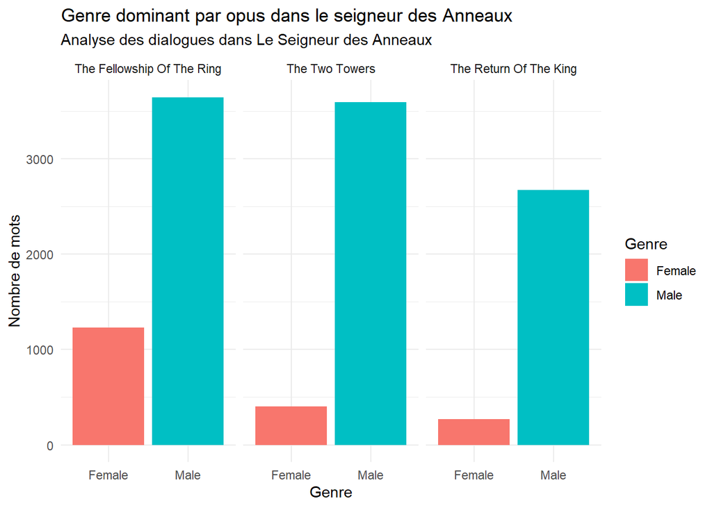

```r
# Faites des trucs ici
  ggplot(data=lotr,aes(x=Sexe,y=Mots,fill=Sexe)) +
  geom_bar(stat="identity",position = "dodge") +
  facet_wrap(~Film)+
  labs(
    title = "Genre dominant par opus dans le seigneur des Anneaux",
    subtitle = "Analyse des dialogues dans Le Seigneur des Anneaux",
    x = "Genre",
    y = "Nombre de mots",
    fill = "Genre"
  )+
  theme_minimal()
```

## Course et cinéma

La race dominante diffère-t-elle d’un film à l’autre ? (Astuce : regrouper à la fois par `Race` et `Film`.) Expérimentez avec le remplissage par `Race` ou `Film` et le facettage par `Race` ou `Film`.

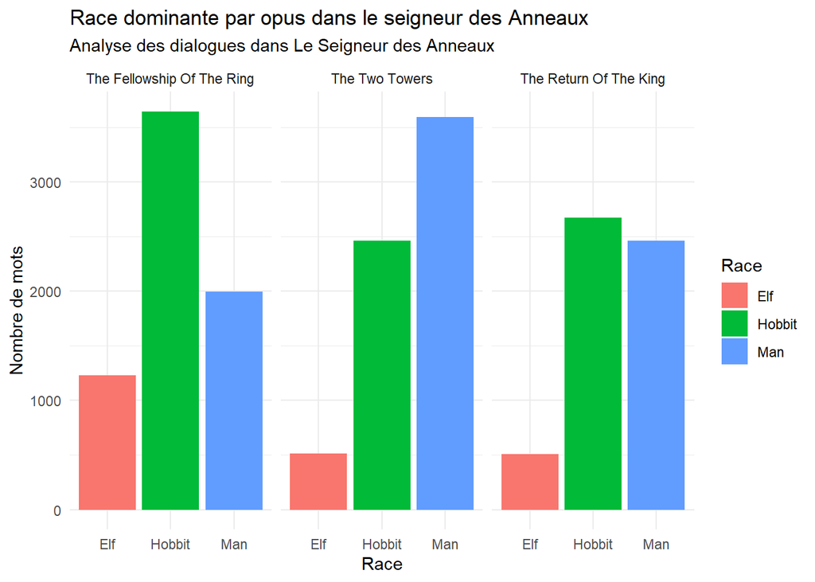

```r
# Faites des trucs ici
ggplot(data=lotr,aes(x=Race,y=Mots,fill=Race)) +
  geom_bar(stat="identity",position = "dodge") +
  facet_wrap(~Film)+
  labs(
    title = "Race dominante par opus dans le seigneur des Anneaux",
    subtitle = "Analyse des dialogues dans Le Seigneur des Anneaux",
    x = "Race",
    y = "Nombre de mots",
    fill = "Race"
  )+
  theme_minimal()
```

## Race et genre et film

Créez un graphique qui visualise simultanément le nombre de mots prononcés par race, sexe et film. Utilisez le bloc de données “lotr” complet. Vous n’avez pas besoin de créer un nouvel ensemble de données résumées (avec `group_by(Race, Gender, Film)`) car les données d’origine ont déjà une ligne pour chacune d’entre elles (vous pourriez créer un ensemble de données résumées, mais il serait identique à la version complète).

Vous devez afficher `Race`, `Gender` et `Film` en même temps, mais vous n’avez que deux esthétiques possibles (`x` et `fill`), vous devrez donc également faire face à la troisième. Jouez avec différentes combinaisons (par exemple, essayez `x = Race`, puis `x = Film`) jusqu’à ce que vous en trouviez une qui raconte l’histoire la plus claire. Pour vous amuser, ajoutez un calque `labs()` pour ajouter un titre, un sous-titre et une légende.

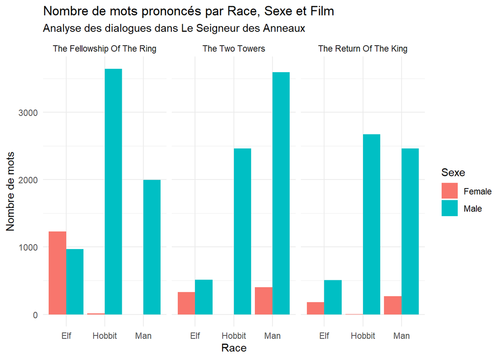

```r
# Faites des trucs ici
ggplot(data = lotr, aes(x=Race,y=Mots,fill=Sexe)) +
  geom_bar(position = "dodge",stat="identity")+
  facet_wrap(~Film,nrow=1)+
  labs(
    title = "Nombre de mots prononcés par Race, Sexe et Film",
    subtitle = "Analyse des dialogues dans Le Seigneur des Anneaux",
    x = "Race",
    y = "Nombre de mots",
    fill = "Sexe"
  ) +
  theme_minimal()
```